# Visualization of Public Health Metrics Around the World (2000-2017)

[figure not shown]

[figure not shown]

[figure not shown]

This dashboards shows how meeting basic dietary needs of people is affected by economic activity (Chart A) and over time, both globally (Chart B) and by region (Chart C).

As Chart A shows, economic activity sizably affects meeting basic dietary needs. Economies with larger activity tend to do much better in meeting dietary needs than those with smaller economic activity do. Since larger economies often exceed minimum requirements (in some cases exceeding by up to by 40%) whereas smaller ones do not meet minimal needs, an opportunity exists for food and economic aid/cooperation to flow from larger to smaller economies to meet dietary needs around the world.

Chart B shows that between 2000 and 2017, the world overall has increasingly met basic dietary needs, even through the great recession of 2009. Chart C, however, highlights important variations in this trend by region. In particular, Africa continues to lag behind other regions, barely meeting minimum dietary needs as a whole. Of impressive note is Asia’s growth in meeting dietary needs. Asia has seen highly robust and accelerated economic development over the last few decades, helping to lift people out of poverty and meet dietary needs. This observation is consistent with what Chart A shows – that higher economic activity is associated with better meeting dietary needs. Note: This does not mean that all countries in a region uniformly meet dietary needs of citizens.

### Chart A

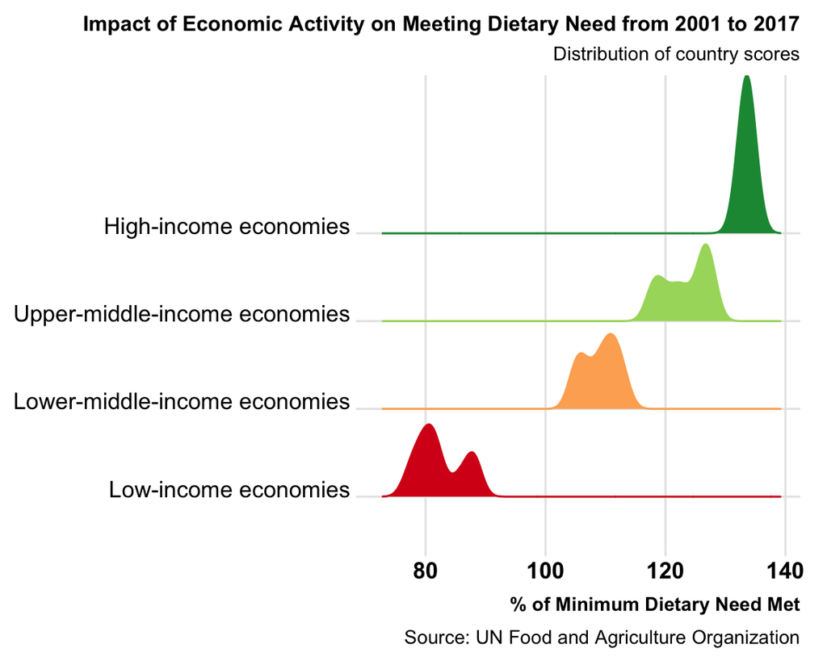

### Chart B

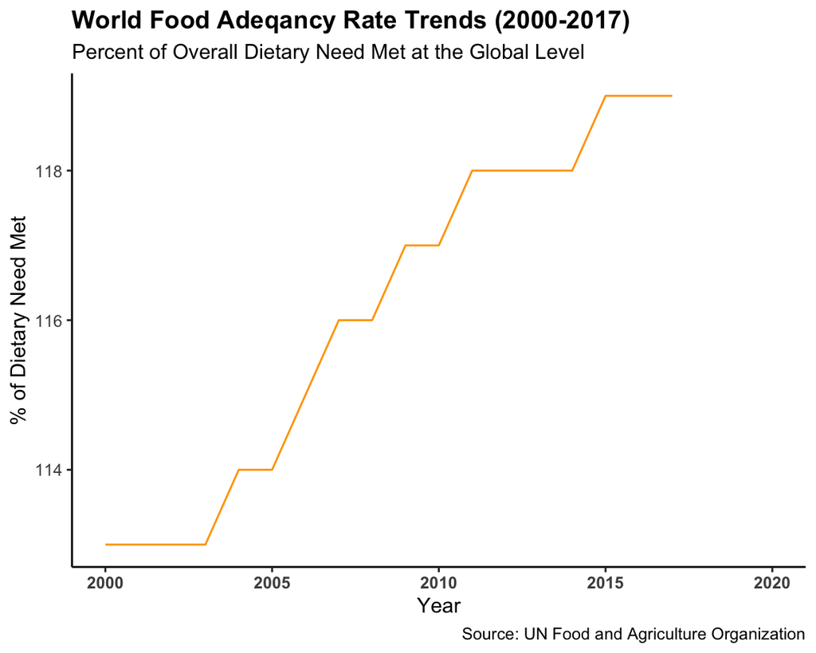

### Chart C

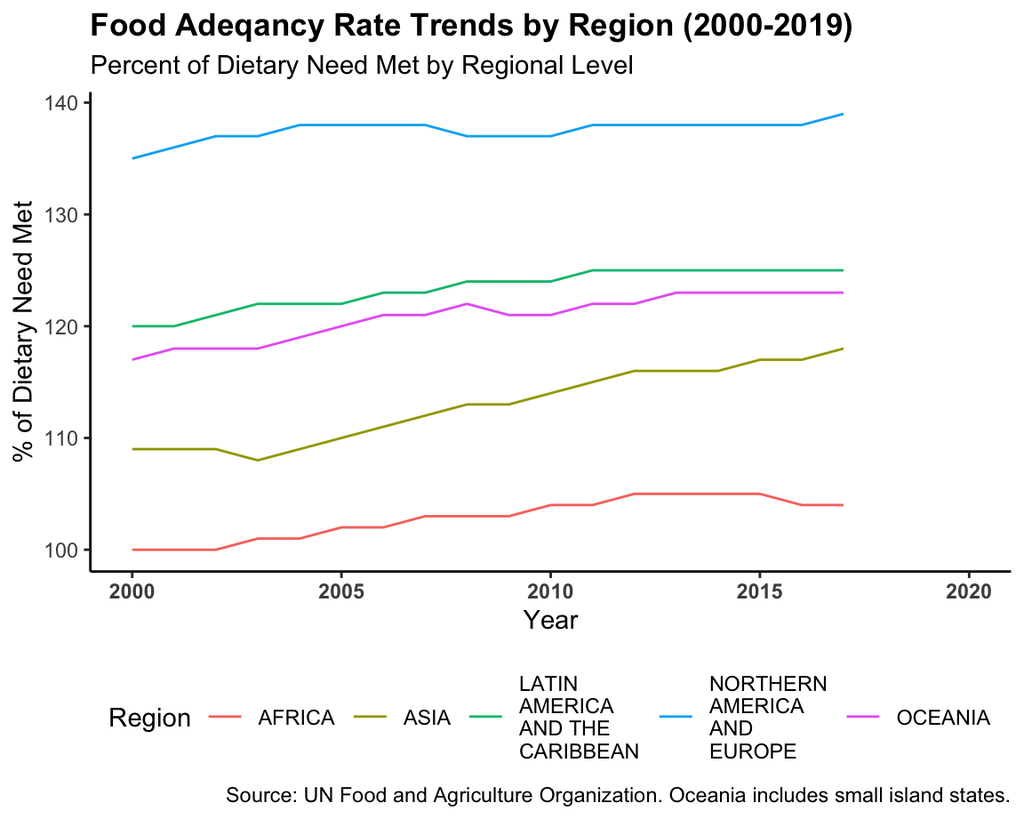